# Zadanie 8

Kacper Prorok

2024-04-21

Za pomocą odpowiednich symulacji zbadać odsetek odrzuceń prawdziwej hipotezy głównej (tzn. błąd I rodzaju) w teście istotności współczynnika korelacji w przypadku, gdy dane pochodzą z rozkładu 𝜒2 irozkładu −1 ∙ 𝜒2 (tzn. generujemy dane z rozkładu 𝜒2 i mnożymy je przez -1).

Przeprowadzę symulacje w 2 wariantach - gdy stopnie swobody dwóch rozkładów są różne i gdy stopnie swobody rozkładów są takie same

# Symulacja 1

Stopnie swobody dwóch rozkładów są różne

## Parametry symulacji

```r
#ilość symulacji
N <- 500
#stopnie swobody rozkładu 1
df1 <- seq(3,31,by=1)
#długość próby
lengths <- c(5,25,100,500)
#stopnie swobody rozkładu 2
df2 <- seq(3,31,by=1)

params <- expand.grid(df1 = df1, df2=df2, length = lengths)
```

## Kod

```r
Spearman<-function(n,df1,df2,K){
  mean(sapply(1:K, function(i) cor.test(rchisq(n,df1),-1*rchisq(n,df2),method="spearman")$p.value<0.05))
}

Pearson<-function(n,df1,df2,K){
 mean(sapply(1:K, function(i) cor.test(rchisq(n,df1),-1*rchisq(n,df2))$p.value<0.05))
}

set.seed(420)

wyniki<-c()
dlugosc<-c(1:nrow(params))
for(i in dlugosc){
  wyniki[i]<-Spearman(params[i,3],params[i,1],params[i,2],500)
}


wyniki1<-c()
dlugosc<-c(1:nrow(params))
for(i in dlugosc){
  wyniki1[i]<-Pearson(params[i,3],params[i,1],params[i,2],500)
}

params<-cbind(params,"Spearman"=wyniki)
params<-cbind(params,"Pearson"=wyniki1)

params<-params%>%
  pivot_longer(cols=c("Spearman","Pearson"),names_to="Test",values_to = "Odsetek")
```

## Wykres 1

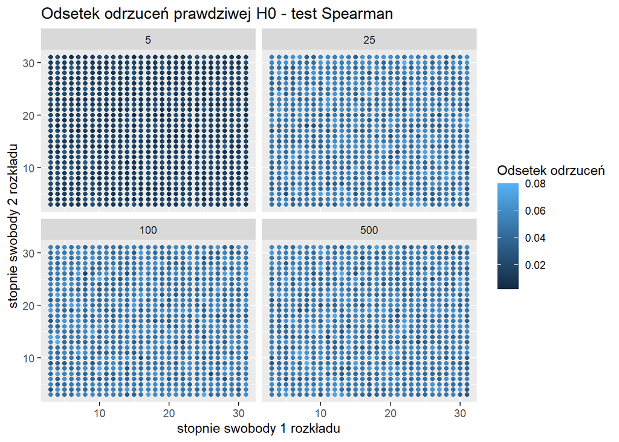

```r
wykres<-params%>%
  filter(Test=="Spearman")%>%
  ggplot()+
  geom_point(aes(x=df1,y=df2,color = Odsetek))+
  facet_wrap(~length)+
  labs(title = "Odsetek odrzuceń prawdziwej H0 - test Spearman",
       x="stopnie swobody 1 rozkładu",
       y="stopnie swobody 2 rozkładu",
       color="Odsetek odrzuceń")
wykres
```

*liczba danych znajduje się nad wykresami*

## Wykres 2

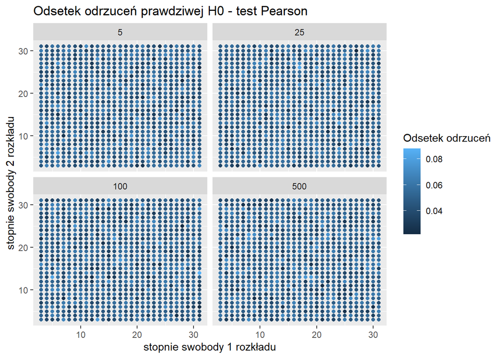

```r
wykres<-params%>%
  filter(Test=="Pearson")%>%
  ggplot()+
  geom_point(aes(x=df1,y=df2,color = Odsetek))+
  facet_wrap(~length)+
  labs(title = "Odsetek odrzuceń prawdziwej H0 - test Pearson",
       x="stopnie swobody 1 rozkładu",
       y="stopnie swobody 2 rozkładu",
       color="Odsetek odrzuceń")
wykres
```

*liczba danych znajduje się nad wykresami*

## Wnioski

- Odsetek odrzuceń w obu testach jest bliski 0.05, czyli poziomu istotności
- Odsetek odrzuceń hipotezy h0 nie zależy od stopni swobody rozkładów
- Odsetek odrzuceń hipotezy h0 nie zależy od liczby danych, jedynie widzimy że dla *małej liczności danych test istotności korelacji Spearmana ma wszędzie niższy odsetek odrzuceń hipotezy H0* - oscyluje on w okolicy 0.02.

# Symulacja 2

Rozkłady mają tyle samo stopni swobody.

## Parametry symulacji

```r
#ilość symulacji
N <- 500
#wartości oczekiwane
df1 <- seq(3,30,by=1)
#długość próby
lengths <- c(5,25,100,500)
params <- expand.grid(df1 = df1, length = lengths)
```

## Kod

```r
Spearman<-function(n,df1,K){
  mean(sapply(1:K, function(i) cor.test(rchisq(n,df1),-1*rchisq(n,df1),method="spearman")$p.value<0.05))
}

Pearson<-function(n,df1,K){
 mean(sapply(1:K, function(i) cor.test(rchisq(n,df1),-1*rchisq(n,df1))$p.value<0.05))
}

set.seed(420)

wyniki<-c()
dlugosc<-c(1:nrow(params))
for(i in dlugosc){
  wyniki[i]<-Spearman(params[i,1],params[i,2],500)
}


wyniki1<-c()
dlugosc<-c(1:nrow(params))
for(i in dlugosc){
  wyniki1[i]<-Pearson(params[i,1],params[i,2],500)
}

params<-cbind(params,"Spearman"=wyniki)
params<-cbind(params,"Pearson"=wyniki1)

params<-params%>%
  pivot_longer(cols=c("Spearman","Pearson"),names_to="Test",values_to = "Odsetek")
```

## Wykres

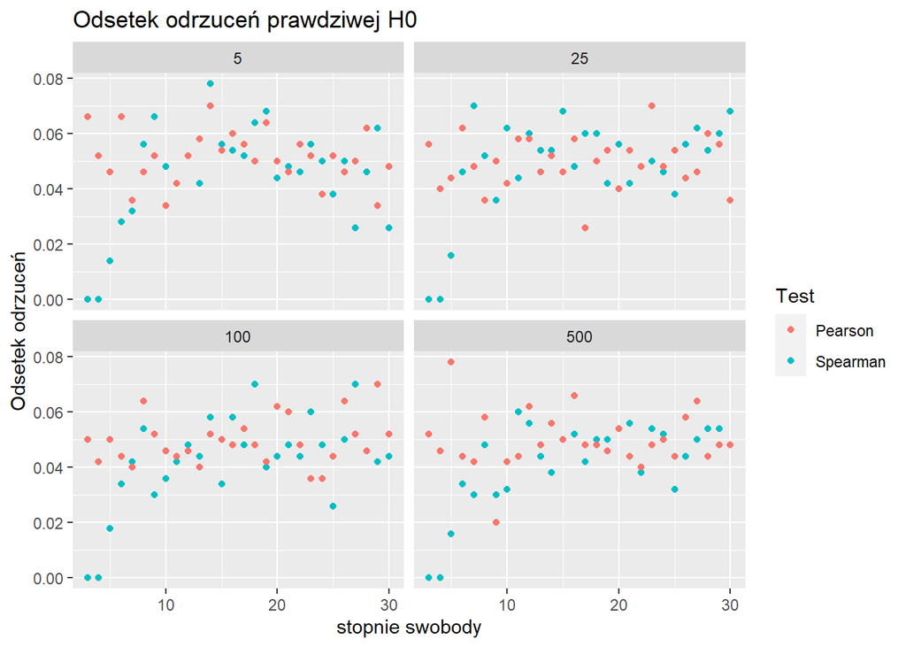

```r
wykres<-params%>%
  ggplot()+
  geom_point(aes(x=df1,y=Odsetek,color = Test))+
  facet_wrap(~length)+
  labs(title = "Odsetek odrzuceń prawdziwej H0",
       x="stopnie swobody",
       y="Odsetek odrzuceń",
       color="Test")
wykres
```